# Principal Components Analysis of Vegetable Nutrients

Julia Dagum

February 5, 2020

This project uses data from the U.S. Department of Agriculture’s (USDA) [FoodData Central](https://fdc.nal.usda.gov/index.html) to conduct principal components analysis (PCA) on nutrients found in vegetables. This analysis explores the relationships between some of the major nutrients found in the USDA food group categorized as “Vegetables and Vegetable Products”. PCA displays multiple dimensions of data in a two-dimensional plane to display the relationships between different variables.

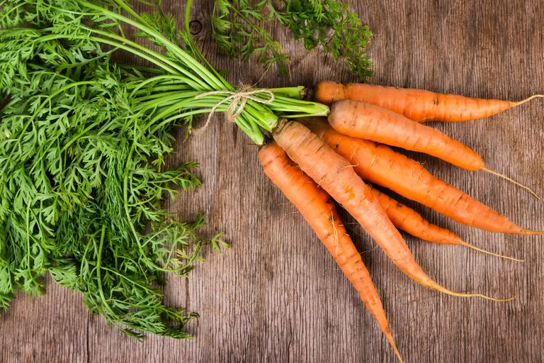

Image Credit: [Getty Images, goodhousekeeping.com](https://www.goodhousekeeping.com/health/diet-nutrition/a48002/carrot-nutrition/)

```r
knitr::opts_chunk$set(echo = TRUE)

# Attach packages

library(tidyverse)
library(janitor)
library(naniar)
library(VIM)
library(skimr)
library(ggfortify)
library(here)
```

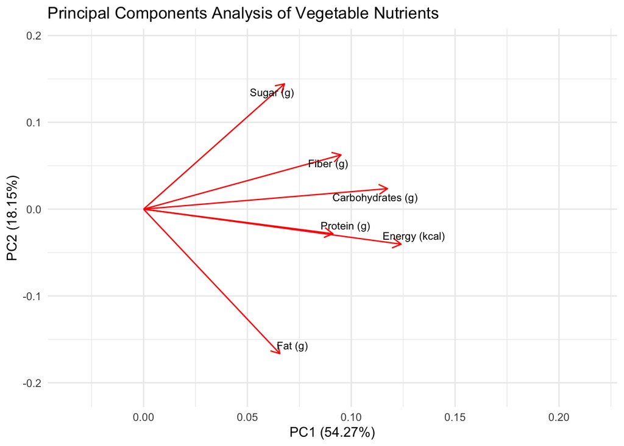

```r
# Read in data

food <- read_csv("usda_nutrients.csv") %>%
  clean_names()

# Make a subset of the data and make sure there are no NA values

food_sub <- food %>%
  filter(food_group == "Vegetables and Vegetable Products") %>%
  select(energy_kcal:fiber_g) %>%
  drop_na()

# Run principal components analysis

veggie_pca <- prcomp(food_sub, scale = TRUE)

# Make a biplot of the data and rename loadings

loadings_names <- c("Energy (kcal)", "Protein (g)", "Fat (g)", "Carbohydrates (g)", "Sugar (g)", "Fiber (g)")

veggie_biplot <- autoplot(veggie_pca,
                      colour = NA,
                      loadings.label = TRUE,
                      loadings.label.size = 3,
                      loadings.label.colour = "black",
                      loadings.label.repel = TRUE,
                      loadings.label.label = loadings_names) +
  theme_minimal() +
  labs(title = "Principal Components Analysis of Vegetable Nutrients")

# Display the biplot

veggie_biplot
```

**Figure 1.** Biplot showing relationships between major nutrients found in the “Vegetables and Vegetable Products” food group of the USDA nutritional information dataset. Vectors pointing the same direction have a strong direct relationship, while vectors at a right angle have a very weak relationship or none at all.

As shown in the biplot, the two principal components in this analysis account for about 72% of the variation in this data.

Data source: U.S. Department of Agriculture, Agricultural Research Service. FoodData Central, 2019. fdc.nal.usda.gov.